# Exploratory statistical analyses

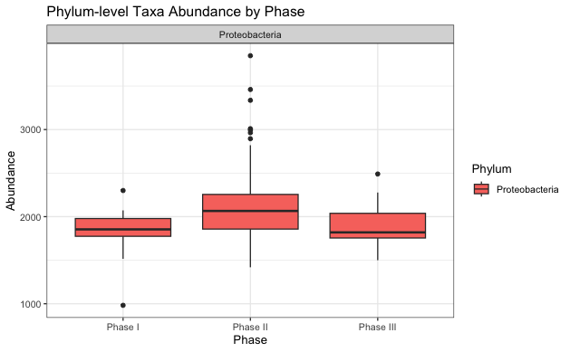

```r
physeq_phylum_melted <- psmelt(proteo)
ggplot(physeq_phylum_melted, aes(x = Phase, y = Abundance, fill = Phylum)) +
  geom_boxplot() +
  facet_wrap(~ Phylum, scales = "free") +  # Facet by Phylum
  theme(axis.text.x = element_text(angle = 45, hjust = 1)) +
  labs(title = "Phylum-level Taxa Abundance by Phase",
       x = "Phase",
       y = "Abundance")+theme_bw()
```

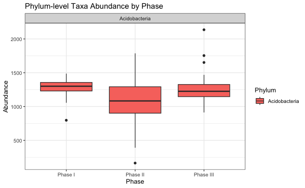

```r
physeq_phylum_melted <- psmelt(acidio)
ggplot(physeq_phylum_melted, aes(x = Phase, y = Abundance, fill = Phylum)) +
  geom_boxplot() +
  facet_wrap(~ Phylum, scales = "free") +  # Facet by Phylum
  theme(axis.text.x = element_text(angle = 45, hjust = 1)) +
  labs(title = "Phylum-level Taxa Abundance by Phase",
       x = "Phase",
       y = "Abundance")+theme_bw()
```

[figure not shown]

edaphic over time (without 55 dap point)

```
md <- data.frame(sample_data(subset_samples(ps16S_bac_rarefy_iter, Timepoint != "t6")))
#ph with regression
ggplot(md) + geom_boxplot(aes(x = time, y = pH, color = Treatment, group = time)) + geom_smooth( data = md, aes(x=time, y = pH, group = "Treatment"), method = "lm", se = F) + facet_wrap("Treatment")
#without regression line
ggplot(md) + geom_boxplot(aes(x = time, y = pH, color = Treatment, group = time)) + facet_wrap("Treatment")

#EC with regression
ggplot(md) + geom_boxplot(aes(x = time, y = EC, color = Treatment, group = time)) + geom_smooth( data = md, aes(x=time, y = EC, group = "Treatment"), method = "lm", se = F) + facet_wrap("Treatment")
#without regression line
ggplot(md) + geom_boxplot(aes(x = time, y = EC, color = Treatment, group = time)) + facet_wrap("Treatment")

#nitrate with regression
ggplot(md) + geom_boxplot(aes(x = time, y = NitrateNperkgDrySoil, color = Treatment, group = time)) + geom_smooth( data = md, aes(x=time, y = NitrateNperkgDrySoil, group = "Treatment"), method = "lm", se = F) + facet_wrap("Treatment")
#without regression line
ggplot(md) + geom_boxplot(aes(x = time, y = NitrateNperkgDrySoil, color = Treatment, group = time)) + facet_wrap("Treatment")

#ammonium with regression
ggplot(md) + geom_boxplot(aes(x = time, y = NH4NperkgDrySoil, color = Treatment, group = time)) + geom_smooth( data = md, aes(x=time, y = NH4NperkgDrySoil, group = "Treatment"), method = "lm", se = F) + facet_wrap("Treatment")
#without regression line
ggplot(md) + geom_boxplot(aes(x = time, y = NH4NperkgDrySoil, color = Treatment, group = time)) + facet_wrap("Treatment")


#non-parametric regression
#Ph
for (i in 1:length(unique(md$Treatment))){
  print(unique(md$Treatment[i]))
  md %>% filter(Treatment == unique(md$Treatment[i])) %>% mblm(pH ~ time, data = .) %>% summary() %>% print()
}

#EC
for (i in 1:length(unique(md$Treatment))){
  print(unique(md$Treatment[i]))
  md %>% filter(Treatment == unique(md$Treatment[i])) %>% mblm(EC ~ time, data = .) %>% summary() %>% print()
}
#nitrate
for (i in 1:length(unique(md$Treatment))){
  print(unique(md$Treatment[i]))
  md %>% filter(Treatment == unique(md$Treatment[i])) %>% mblm(NitrateNperkgDrySoil ~ time, data = .) %>% summary() %>% print()
}
#ammonium
for (i in 1:length(unique(md$Treatment))){
  print(unique(md$Treatment[i]))
  md %>% filter(Treatment == unique(md$Treatment[i])) %>% mblm(NH4NperkgDrySoil ~ time, data = .) %>% summary() %>% print()
}
```

ordination of edaphic conditions (without 55 dap point)

```
#switch md to either include or exclude t 55 days
md <- data.frame(sample_data(subset_samples(ps16S_bac_rarefy_iter, Timepoint != "t6")))
#md <- data.frame(sample_data(ps16S_bac_rarefy_iter)

#standardize edaphic conditions

md_heatmap <- md %>% select(time, Treatment, pH, EC, NitrateN, AmmoniumN) %>% filter(time != 0)
md_heatmap[,3:6] <- scale(md_heatmap[,3:6],center = T, scale = T)
ord <- metaMDS(md_heatmap[,3:6], distance = "euclidian" , data = md_heatmap[,3:6])

plot(ord, display = "sites")

dune.fit <- envfit(ord ~ pH + EC + NitrateN + AmmoniumN, md_heatmap[,3:6],
                   choices=c(1:2))
dune.fit

#base R plot
plot(ord, display = "sites", type = "n")
points(ord, display = "sites", col = "black", cex = 1.25)
plot(dune.fit)

spp.scrs <- as.data.frame(scores(dune.fit, display = "vectors"))
spp.scrs <- cbind(spp.scrs, Species = rownames(spp.scrs))

df <-data.frame(ord$points)
df$time <- md_heatmap$time
df$treatment <- md_heatmap$Treatment
df$pH <- md_heatmap$pH
  ggplot(data=df, aes(x=MDS1, y=MDS2)) + theme_bw(16) +
            labs(x="MDS Axis 1",y="MDS Axis 2") +
            theme(panel.grid=element_blank()) + geom_point(aes(shape=as.factor(time), color = treatment), size = 7) +
  coord_fixed() + ## need aspect ratio of 1!
  geom_segment(data = spp.scrs,
               aes(x = 0, xend = NMDS1, y = 0, yend = NMDS2),
               arrow = arrow(length = unit(0.25, "cm")), colour = "grey") +
  geom_text(data = spp.scrs, aes(x = NMDS1, y = NMDS2, label = Species),
            size = 3)

md_dist <- dist(md[,c("pH", "EC", "NitrateNperkgDrySoil", "NH4NperkgDrySoil")], method = "euclidean")
adonis2(md_dist~ Covercrop + WheatM + Timepoint, data = md, strata = md$Timepoint)
#pairwiseAdonis::pairwise.adonis2(md_dist ~ Treatment, data = md, strata = md$Timepoint)
```

heat map of edaphic conditions

```r
#switch md to either include or exclude t 55 days
#md <- data.frame(sample_data(subset_samples(ps16S_bac_rarefy_iter, Timepoint != "t6")))
md <- data.frame(sample_data(ps16S_bac_rarefy_iter))

md_heatmap <- md %>% select(time, Treatment, pH, EC, NitrateN, AmmoniumN) %>% filter(time != 0)
#to remove time 0 if we look at nitrate and ammonia values bc they are missing at t0
#md_heatmap <- md %>% select(time, Treatment, pH, EC, NitrateNperkgDrySoil, NH4NperkgDrySoil) %>% filter(time != 0)

#standardize
md_heatmap[,3:6] <- scale(md_heatmap[,3:6],center = T, scale = T)

heatmap(as.matrix(md_heatmap[3:6]), scale = "column", Colv = NA, Rowv = NA)
```

#Community data

#Alpha Diversity Alpha diversity over time (with 55 dap point)

```
alphadiv<-estimate_richness(ps16S_bac_rarefy_iter)
alphadiv$treatment <- sample_data(ps16S_bac_rarefy_iter)$Treatment
alphadiv$time <- sample_data(ps16S_bac_rarefy_iter)$time
alphadiv$wheatm <- sample_data(ps16S_bac_rarefy_iter)$WheatM
alphadiv$pH <- sample_data(ps16S_bac_rarefy_iter)$pH

ggplot(alphadiv) + geom_boxplot(aes(x = time, y = Observed, color = treatment, group = time)) + geom_smooth( data = alphadiv, aes(x=time, y = Observed, group = "treatment"), method = "lm", se = F) + facet_wrap("treatment")

#lm but wont meet requirements of lm
for (i in 1:length(unique(alphadiv$treatment))){
  print(unique(alphadiv$treatment[i]))
  alphadiv %>% filter(treatment == unique(alphadiv$treatment[i])) %>% lm(Observed ~ time, data = .) %>% summary() %>% print() %>% residuals() %>% hist()
}

#non-parametric regression
for (i in 1:length(unique(alphadiv$treatment))){
  print(unique(alphadiv$treatment[i]))
  alphadiv %>% filter(treatment == unique(alphadiv$treatment[i])) %>% mblm(Observed ~ time, data = .) %>% summary() %>% print()
}
```

Alpha diversity over time

```r
#without 55 days after planting point
alphadiv<-estimate_richness(subset_samples(ps16S_bac_rarefy_iter, Timepoint != "t6"))
alphadiv$treatment <- sample_data(subset_samples(ps16S_bac_rarefy_iter, Timepoint != "t6"))$Treatment
alphadiv$time <- sample_data(subset_samples(ps16S_bac_rarefy_iter, Timepoint != "t6"))$time
alphadiv$wheatm <- sample_data(subset_samples(ps16S_bac_rarefy_iter, Timepoint != "t6"))$WheatM
alphadiv$pH <- sample_data(subset_samples(ps16S_bac_rarefy_iter, Timepoint != "t6"))$pH

ggplot(alphadiv) + geom_boxplot(aes(x = time, y = Observed, color = treatment, group = time)) + geom_smooth( data = alphadiv, aes(x=time, y = Observed, group = "treatment"), method = "lm", se = F) + facet_wrap("treatment")

ggplot(alphadiv) + geom_boxplot(aes(x = time, y = Shannon, color = treatment, group = time)) + geom_smooth( data = alphadiv, aes(x=time, y = Shannon, group = "treatment"), method = "lm", se = F) + facet_wrap("treatment")

ggplot(alphadiv) + geom_boxplot(aes(x = time, y = Simpson, color = treatment, group = time)) + geom_smooth( data = alphadiv, aes(x=time, y = Simpson, group = "treatment"), method = "lm", se = F) + facet_wrap("treatment")

#lm but wont meet requirements of lm
#for (i in 1:length(unique(alphadiv$treatment))){
#  print(unique(alphadiv$treatment[i]))
#  alphadiv %>% filter(treatment == unique(alphadiv$treatment[i])) %>% lm(Observed ~ time, data = .) %>% summary() %>% print() %>% residuals() %>% hist()
#}

#non-parametric regression
for (i in 1:length(unique(alphadiv$treatment))){
  print(unique(alphadiv$treatment[i]))
  alphadiv %>% filter(treatment == unique(alphadiv$treatment[i])) %>% mblm(Observed ~ time, data = .) %>% summary() %>% print()
}

for (i in 1:length(unique(alphadiv$treatment))){
  print(unique(alphadiv$treatment[i]))
  alphadiv %>% filter(treatment == unique(alphadiv$treatment[i])) %>% mblm(Shannon ~ time, data = .) %>% summary() %>% print()
}

for (i in 1:length(unique(alphadiv$treatment))){
  print(unique(alphadiv$treatment[i]))
  alphadiv %>% filter(treatment == unique(alphadiv$treatment[i])) %>% mblm(Simpson ~ time, data = .) %>% summary() %>% print()
}
```

#beta-diversity (without 55 dap point)

```r
com_ord <- ordinate(subset_samples(ps16S_bac_rarefy_iter, Timepoint != "t6"), method = "NMDS", distance = "bray", k = 3)
ord_plot<-plot_ordination(ps16S_bac_rarefy_iter, ordination = com_ord, type = "samples", axes = 1:2, color = "Treatment", shape = "Timepoint")

com_df_nmds<-data.frame(com_ord$points)
com_df_nmds$pH <- sample_data(subset_samples(ps16S_bac_rarefy_iter, Timepoint != "t6"))$pH
com_df_nmds$EC <- sample_data(subset_samples(ps16S_bac_rarefy_iter, Timepoint != "t6"))$EC
com_df_nmds$NitrateN <- sample_data(subset_samples(ps16S_bac_rarefy_iter, Timepoint != "t6"))$NitrateN
com_df_nmds$timepoint <- sample_data(subset_samples(ps16S_bac_rarefy_iter, Timepoint != "t6"))$Timepoint
com_df_nmds$treatment<- sample_data(subset_samples(ps16S_bac_rarefy_iter, Timepoint != "t6"))$Treatment
com_df_nmds$covercrop <- sample_data(subset_samples(ps16S_bac_rarefy_iter, Timepoint != "t6"))$Covercrop
com_df_nmds$wheatm <- sample_data(subset_samples(ps16S_bac_rarefy_iter, Timepoint != "t6"))$WheatM
com_df_nmds$time <- sample_data(subset_samples(ps16S_bac_rarefy_iter, Timepoint != "t6"))$time
#plot nmds
plot(com_df_nmds$MDS1 ~ com_df_nmds$pH)
ggplot(com_df_nmds, aes(x = MDS1, y = pH, color = treatment, shape = timepoint, alpha = pH)) + geom_point(aes(size=7)) + theme_classic()


#axis 1 with pH
summary(lm(com_df_nmds$MDS1 ~ com_df_nmds$pH))
hist(residuals(lm(com_df_nmds$MDS1 ~ com_df_nmds$pH)))
#looks normal enough, but just in case heres a non-parametric regression
summary(mblm(MDS1 ~ pH, dataframe = com_df_nmds))
#summary(lm(com_df_nmds$MDS1 ~ com_df_nmds$pH, dataframe = com_df_nmds))
```

global adonis testing

```r
ps_adonis<-function(physeq){
  otu_tab<-data.frame(phyloseq::otu_table(physeq))
  md_tab<-data.frame(phyloseq::sample_data(physeq))
    if(taxa_are_rows(physeq)== T){
       physeq_dist<-parallelDist::parDist(as.matrix(t(otu_tab)), method = "bray")}
            else{physeq_dist<-parallelDist::parDist(as.matrix(otu_tab), method = "bray")}
  print(anova(vegan::betadisper(physeq_dist, md_tab$Treatment)))
  vegan::adonis2(physeq_dist ~ pH + WheatM + Covercrop + Timepoint, data = md_tab, permutations = 100)
}
ps_adonis(ps16S_bac_rarefy_iter)

ps_adonis(subset_samples(ps16S_bac_rarefy_iter, Timepoint != "t6"))


ps_pairwiseadonis<-function(physeq){
  otu_tab<-data.frame(phyloseq::otu_table(physeq))
  md_tab<-data.frame(phyloseq::sample_data(physeq))
    if(taxa_are_rows(physeq)== T){
       physeq_dist<-parallelDist::parDist(as.matrix(t(otu_tab)), method = "bray")}
            else{physeq_dist<-parallelDist::parDist(as.matrix(otu_tab), method = "bray")}
print(pairwiseAdonis::pairwise.adonis(x = physeq_dist, factors = md_tab$Treatment, p.adjust.m = "fdr", perm = 100))
print(pairwiseAdonis::pairwise.adonis(x = physeq_dist, factors = md_tab$WheatM, p.adjust.m = "fdr", perm = 100))
print(pairwiseAdonis::pairwise.adonis(x = physeq_dist, factors = md_tab$Covercrop, p.adjust.m = "fdr", perm = 100))

}

ps_pairwiseadonis(ps16S_bac_rarefy_iter)
ps_pairwiseadonis(subset_samples(ps16S_bac_rarefy_iter, Timepoint != "t6"))
```

#split a few time points and see trends

index <- c(“t0”, “t1”, “t2”, “t3”, “t4”, “t5”, “t6”) values <- c(“0”, “2”, “5”, “7”, “14”, “21”, “55”)

day 0

```r
com_ord <- ordinate(subset_samples(ps16S_bac_rarefy_iter, Timepoint == "t0"), method = "NMDS", distance = "bray", k = 3)
#ord_plot<-plot_ordination(ps16S_bac_rarefy_iter, ordination = com_ord, type = "samples", axes = 1:2, color = "Treatment", shape = "Timepoint")

com_df_nmds<-data.frame(com_ord$points)
com_df_nmds$pH <- sample_data(subset_samples(ps16S_bac_rarefy_iter, Timepoint == "t0"))$pH
com_df_nmds$EC <- sample_data(subset_samples(ps16S_bac_rarefy_iter, Timepoint == "t0"))$EC
com_df_nmds$pH <- sample_data(subset_samples(ps16S_bac_rarefy_iter, Timepoint == "t0"))$pH
com_df_nmds$timepoint <- sample_data(subset_samples(ps16S_bac_rarefy_iter, Timepoint == "t0"))$Timepoint
com_df_nmds$treatment<- sample_data(subset_samples(ps16S_bac_rarefy_iter, Timepoint == "t0"))$Treatment
com_df_nmds$covercrop <- sample_data(subset_samples(ps16S_bac_rarefy_iter, Timepoint == "t0"))$Covercrop
com_df_nmds$wheatm <- sample_data(subset_samples(ps16S_bac_rarefy_iter, Timepoint == "t0"))$WheatM
com_df_nmds$time <- sample_data(subset_samples(ps16S_bac_rarefy_iter, Timepoint == "t0"))$time
#plot nmds with colors etc

ggplot(com_df_nmds, aes(x = MDS1, y = MDS2, color = treatment, shape = timepoint, alpha = pH)) + geom_point(aes(size=7)) + theme_classic()

ps_adonis<-function(physeq){
  otu_tab<-data.frame(phyloseq::otu_table(physeq))
  md_tab<-data.frame(phyloseq::sample_data(physeq))
    if(taxa_are_rows(physeq)== T){
       physeq_dist<-parallelDist::parDist(as.matrix(t(otu_tab)), method = "bray")}
            else{physeq_dist<-parallelDist::parDist(as.matrix(otu_tab), method = "bray")}
  print(anova(vegan::betadisper(physeq_dist, md_tab$Treatment)))
  vegan::adonis2(physeq_dist ~ pH + WheatM * Covercrop, data = md_tab, permutations = 100)
}

ps_adonis(subset_samples(ps16S_bac_rarefy_iter, Timepoint == "t0"))



ps_pairwiseadonis(subset_samples(ps16S_bac_rarefy_iter, Timepoint == "t0"))
```

day 2 index <- c(“t0”, “t1”, “t2”, “t3”, “t4”, “t5”, “t6”) values <- c(“0”, “2”, “5”, “7”, “14”, “21”, “55”)

```r
com_ord <- ordinate(subset_samples(ps16S_bac_rarefy_iter, Timepoint == "t1"), method = "NMDS", distance = "bray", k = 3)
#ord_plot<-plot_ordination(ps16S_bac_rarefy_iter, ordination = com_ord, type = "samples", axes = 1:2, color = "Treatment", shape = "Timepoint")

com_df_nmds<-data.frame(com_ord$points)
com_df_nmds$pH <- sample_data(subset_samples(ps16S_bac_rarefy_iter, Timepoint == "t1"))$pH
com_df_nmds$EC <- sample_data(subset_samples(ps16S_bac_rarefy_iter, Timepoint == "t1"))$EC
com_df_nmds$pH <- sample_data(subset_samples(ps16S_bac_rarefy_iter, Timepoint == "t1"))$pH
com_df_nmds$timepoint <- sample_data(subset_samples(ps16S_bac_rarefy_iter, Timepoint == "t1"))$Timepoint
com_df_nmds$treatment<- sample_data(subset_samples(ps16S_bac_rarefy_iter, Timepoint == "t1"))$Treatment
com_df_nmds$covercrop <- sample_data(subset_samples(ps16S_bac_rarefy_iter, Timepoint == "t1"))$Covercrop
com_df_nmds$wheatm <- sample_data(subset_samples(ps16S_bac_rarefy_iter, Timepoint == "t1"))$WheatM
com_df_nmds$time <- sample_data(subset_samples(ps16S_bac_rarefy_iter, Timepoint == "t1"))$time
#plot nmds with colors etc

ggplot(com_df_nmds, aes(x = MDS1, y = MDS2, color = treatment, shape = timepoint, alpha = pH)) + geom_point(aes(size=7)) + theme_classic()

ps_adonis<-function(physeq){
  otu_tab<-data.frame(phyloseq::otu_table(physeq))
  md_tab<-data.frame(phyloseq::sample_data(physeq))
    if(taxa_are_rows(physeq)== T){
       physeq_dist<-parallelDist::parDist(as.matrix(t(otu_tab)), method = "bray")}
            else{physeq_dist<-parallelDist::parDist(as.matrix(otu_tab), method = "bray")}
  print(anova(vegan::betadisper(physeq_dist, md_tab$Treatment)))
  vegan::adonis2(physeq_dist ~  pH + WheatM * Covercrop , data = md_tab, permutations = 100)
}

ps_adonis(subset_samples(ps16S_bac_rarefy_iter, Timepoint == "t1"))


ps_pairwiseadonis(subset_samples(ps16S_bac_rarefy_iter, Timepoint == "t1"))
```

day 7 index <- c(“t0”, “t1”, “t2”, “t3”, “t4”, “t5”, “t6”) values <- c(“0”, “2”, “5”, “7”, “14”, “21”, “55”)

```r
com_ord <- ordinate(subset_samples(ps16S_bac_rarefy_iter, Timepoint == "t3"), method = "NMDS", distance = "bray", k = 3)
#ord_plot<-plot_ordination(ps16S_bac_rarefy_iter, ordination = com_ord, type = "samples", axes = 1:2, color = "Treatment", shape = "Timepoint")

com_df_nmds<-data.frame(com_ord$points)
com_df_nmds$pH <- sample_data(subset_samples(ps16S_bac_rarefy_iter, Timepoint == "t3"))$pH
com_df_nmds$EC <- sample_data(subset_samples(ps16S_bac_rarefy_iter, Timepoint == "t3"))$EC
com_df_nmds$pH <- sample_data(subset_samples(ps16S_bac_rarefy_iter, Timepoint == "t3"))$pH
com_df_nmds$timepoint <- sample_data(subset_samples(ps16S_bac_rarefy_iter, Timepoint == "t3"))$Timepoint
com_df_nmds$treatment<- sample_data(subset_samples(ps16S_bac_rarefy_iter, Timepoint == "t3"))$Treatment
com_df_nmds$covercrop <- sample_data(subset_samples(ps16S_bac_rarefy_iter, Timepoint == "t3"))$Covercrop
com_df_nmds$wheatm <- sample_data(subset_samples(ps16S_bac_rarefy_iter, Timepoint == "t3"))$WheatM
com_df_nmds$time <- sample_data(subset_samples(ps16S_bac_rarefy_iter, Timepoint == "t3"))$time
#plot nmds with colors etc

ggplot(com_df_nmds, aes(x = MDS1, y = MDS2, color = treatment, shape = timepoint, alpha = pH)) + geom_point(aes(size=7)) + theme_classic()

ps_adonis<-function(physeq){
  otu_tab<-data.frame(phyloseq::otu_table(physeq))
  md_tab<-data.frame(phyloseq::sample_data(physeq))
    if(taxa_are_rows(physeq)== T){
       physeq_dist<-parallelDist::parDist(as.matrix(t(otu_tab)), method = "bray")}
            else{physeq_dist<-parallelDist::parDist(as.matrix(otu_tab), method = "bray")}
  print(anova(vegan::betadisper(physeq_dist, md_tab$Treatment)))
  vegan::adonis2(physeq_dist ~ pH + WheatM * Covercrop , data = md_tab, permutations = 100)
}

ps_adonis(subset_samples(ps16S_bac_rarefy_iter, Timepoint == "t3"))
ps_pairwiseadonis(subset_samples(ps16S_bac_rarefy_iter, Timepoint == "t3"))
```

day 14 index <- c(“t0”, “t1”, “t2”, “t3”, “t4”, “t5”, “t6”) values <- c(“0”, “2”, “5”, “7”, “14”, “21”, “55”)

```r
com_ord <- ordinate(subset_samples(ps16S_bac_rarefy_iter, Timepoint == "t4"), method = "NMDS", distance = "bray", k = 3)
#ord_plot<-plot_ordination(ps16S_bac_rarefy_iter, ordination = com_ord, type = "samples", axes = 1:2, color = "Treatment", shape = "Timepoint")

com_df_nmds<-data.frame(com_ord$points)
com_df_nmds$pH <- sample_data(subset_samples(ps16S_bac_rarefy_iter, Timepoint == "t4"))$pH
com_df_nmds$EC <- sample_data(subset_samples(ps16S_bac_rarefy_iter, Timepoint == "t4"))$EC
com_df_nmds$pH <- sample_data(subset_samples(ps16S_bac_rarefy_iter, Timepoint == "t4"))$pH
com_df_nmds$timepoint <- sample_data(subset_samples(ps16S_bac_rarefy_iter, Timepoint == "t4"))$Timepoint
com_df_nmds$treatment<- sample_data(subset_samples(ps16S_bac_rarefy_iter, Timepoint == "t4"))$Treatment
com_df_nmds$covercrop <- sample_data(subset_samples(ps16S_bac_rarefy_iter, Timepoint == "t4"))$Covercrop
com_df_nmds$wheatm <- sample_data(subset_samples(ps16S_bac_rarefy_iter, Timepoint == "t4"))$WheatM
com_df_nmds$time <- sample_data(subset_samples(ps16S_bac_rarefy_iter, Timepoint == "t4"))$time
#plot nmds with colors etc

ggplot(com_df_nmds, aes(x = MDS1, y = MDS2, color = treatment, shape = timepoint, alpha = pH)) + geom_point(aes(size=7)) + theme_classic()

ps_adonis<-function(physeq){
  otu_tab<-data.frame(phyloseq::otu_table(physeq))
  md_tab<-data.frame(phyloseq::sample_data(physeq))
    if(taxa_are_rows(physeq)== T){
       physeq_dist<-parallelDist::parDist(as.matrix(t(otu_tab)), method = "bray")}
            else{physeq_dist<-parallelDist::parDist(as.matrix(otu_tab), method = "bray")}
  print(anova(vegan::betadisper(physeq_dist, md_tab$Treatment)))
  vegan::adonis2(physeq_dist ~ pH + WheatM * Covercrop, data = md_tab, permutations = 100)
}

ps_adonis(subset_samples(ps16S_bac_rarefy_iter, Timepoint == "t4"))
ps_pairwiseadonis(subset_samples(ps16S_bac_rarefy_iter, Timepoint == "t4"))
```

index <- c(“t0”, “t1”, “t2”, “t3”, “t4”, “t5”, “t6”) values <- c(“0”, “2”, “5”, “7”, “14”, “21”, “55”)

```r
com_ord <- ordinate(subset_samples(ps16S_bac_rarefy_iter, Timepoint == "t5"), method = "NMDS", distance = "bray", k = 3)
#ord_plot<-plot_ordination(ps16S_bac_rarefy_iter, ordination = com_ord, type = "samples", axes = 1:2, color = "Treatment", shape = "Timepoint")

com_df_nmds<-data.frame(com_ord$points)
com_df_nmds$pH <- sample_data(subset_samples(ps16S_bac_rarefy_iter, Timepoint == "t5"))$pH
com_df_nmds$EC <- sample_data(subset_samples(ps16S_bac_rarefy_iter, Timepoint == "t5"))$EC
com_df_nmds$pH <- sample_data(subset_samples(ps16S_bac_rarefy_iter, Timepoint == "t5"))$pH
com_df_nmds$timepoint <- sample_data(subset_samples(ps16S_bac_rarefy_iter, Timepoint == "t5"))$Timepoint
com_df_nmds$treatment<- sample_data(subset_samples(ps16S_bac_rarefy_iter, Timepoint == "t5"))$Treatment
com_df_nmds$covercrop <- sample_data(subset_samples(ps16S_bac_rarefy_iter, Timepoint == "t5"))$Covercrop
com_df_nmds$wheatm <- sample_data(subset_samples(ps16S_bac_rarefy_iter, Timepoint == "t5"))$WheatM
com_df_nmds$time <- sample_data(subset_samples(ps16S_bac_rarefy_iter, Timepoint == "t5"))$time
#plot nmds with colors etc

ggplot(com_df_nmds, aes(x = MDS1, y = MDS2, color = treatment, shape = wheatm, alpha=pH)) + geom_point(aes(size=7)) + theme_classic() + scale_color_manual(values = col_vector)

ps_adonis<-function(physeq){
  otu_tab<-data.frame(phyloseq::otu_table(physeq))
  md_tab<-data.frame(phyloseq::sample_data(physeq))
    if(taxa_are_rows(physeq)== T){
       physeq_dist<-parallelDist::parDist(as.matrix(t(otu_tab)), method = "bray")}
            else{physeq_dist<-parallelDist::parDist(as.matrix(otu_tab), method = "bray")}
  print(anova(vegan::betadisper(physeq_dist, md_tab$Treatment)))
  vegan::adonis2(physeq_dist ~ pH + WheatM * Covercrop , data = md_tab, permutations = 100)
}

ps_adonis(subset_samples(ps16S_bac_rarefy_iter, Timepoint == "t5"))
ps_pairwiseadonis(subset_samples(ps16S_bac_rarefy_iter, Timepoint == "t5"))
```

index <- c(“t0”, “t1”, “t2”, “t3”, “t4”, “t5”, “t6”) values <- c(“0”, “2”, “5”, “7”, “14”, “21”, “55”)

after planting (55 dat)

```r
com_ord <- ordinate(subset_samples(ps16S_bac_rarefy_iter, Timepoint == "t6"), method = "NMDS", distance = "bray", k = 3)
#ord_plot<-plot_ordination(ps16S_bac_rarefy_iter, ordination = com_ord, type = "samples", axes = 1:2, color = "Treatment", shape = "Timepoint")

com_df_nmds<-data.frame(com_ord$points)
com_df_nmds$pH <- sample_data(subset_samples(ps16S_bac_rarefy_iter, Timepoint == "t6"))$pH
com_df_nmds$EC <- sample_data(subset_samples(ps16S_bac_rarefy_iter, Timepoint == "t6"))$EC
com_df_nmds$pH <- sample_data(subset_samples(ps16S_bac_rarefy_iter, Timepoint == "t6"))$pH
com_df_nmds$timepoint <- sample_data(subset_samples(ps16S_bac_rarefy_iter, Timepoint == "t6"))$Timepoint
com_df_nmds$treatment<- sample_data(subset_samples(ps16S_bac_rarefy_iter, Timepoint == "t6"))$Treatment
com_df_nmds$covercrop <- sample_data(subset_samples(ps16S_bac_rarefy_iter, Timepoint == "t6"))$Covercrop
com_df_nmds$wheatm <- sample_data(subset_samples(ps16S_bac_rarefy_iter, Timepoint == "t6"))$WheatM
com_df_nmds$time <- sample_data(subset_samples(ps16S_bac_rarefy_iter, Timepoint == "t6"))$time
#plot nmds with colors etc

ggplot(com_df_nmds, aes(x = MDS1, y = MDS2, color = treatment, shape = wheatm, alpha=pH)) + geom_point(aes(size=7)) + theme_classic() + scale_color_manual(values = col_vector)

ps_adonis<-function(physeq){
  otu_tab<-data.frame(phyloseq::otu_table(physeq))
  md_tab<-data.frame(phyloseq::sample_data(physeq))
    if(taxa_are_rows(physeq)== T){
       physeq_dist<-parallelDist::parDist(as.matrix(t(otu_tab)), method = "bray")}
            else{physeq_dist<-parallelDist::parDist(as.matrix(otu_tab), method = "bray")}
  print(anova(vegan::betadisper(physeq_dist, md_tab$Treatment)))
  vegan::adonis2(physeq_dist ~ pH + WheatM * Covercrop , data = md_tab, permutations = 100)
}

ps_adonis(subset_samples(ps16S_bac_rarefy_iter, Timepoint == "t6"))
ps_pairwiseadonis(subset_samples(ps16S_bac_rarefy_iter, Timepoint == "t6"))
```

Compare t0 and t5 to see if treatments result in deviation

```r
ps_subset <- ps16S_bac_rarefy_iter %>% subset_samples(Timepoint != "t1") %>% subset_samples(Timepoint != "t2") %>% subset_samples(Timepoint != "t3") %>% subset_samples(Timepoint != "t4") %>% subset_samples(Timepoint != "t6")
sample_data(ps_subset)

ps_adonis<-function(physeq){
  otu_tab<-data.frame(phyloseq::otu_table(physeq))
  md_tab<-data.frame(phyloseq::sample_data(physeq))
    if(taxa_are_rows(physeq)== T){
       physeq_dist<-parallelDist::parDist(as.matrix(t(otu_tab)), method = "bray")}
            else{physeq_dist<-parallelDist::parDist(as.matrix(otu_tab), method = "bray")}
  print(anova(vegan::betadisper(physeq_dist, md_tab$Treatment)))
  vegan::adonis2(physeq_dist ~ pH + WheatM + Covercrop + Timepoint, data = md_tab, permutations = 100)
}

ps_adonis(ps_subset)

ps_pairwiseadonis<-function(physeq){
  otu_tab<-data.frame(phyloseq::otu_table(physeq))
  md_tab<-data.frame(phyloseq::sample_data(physeq))
    if(taxa_are_rows(physeq)== T){
       physeq_dist<-parallelDist::parDist(as.matrix(t(otu_tab)), method = "bray")}
            else{physeq_dist<-parallelDist::parDist(as.matrix(otu_tab), method = "bray")}
print(pairwiseAdonis::pairwise.adonis(x = physeq_dist, factors = md_tab$Treatment, p.adjust.m = "fdr", perm = 100))
print(pairwiseAdonis::pairwise.adonis(x = physeq_dist, factors = md_tab$WheatM, p.adjust.m = "fdr", perm = 100))
print(pairwiseAdonis::pairwise.adonis(x = physeq_dist, factors = md_tab$Covercrop, p.adjust.m = "fdr", perm = 100))
print(pairwiseAdonis::pairwise.adonis(x = physeq_dist, factors = md_tab$Timepoint, p.adjust.m = "fdr", perm = 100))
}

ps_pairwiseadonis(ps_subset)

com_ord <- ordinate(ps_subset, method = "NMDS", distance = "bray", k = 3)
#ord_plot<-plot_ordination(ps16S_bac_rarefy_iter, ordination = com_ord, type = "samples", axes = 1:2, color = "Treatment", shape = "Timepoint")

com_df_nmds<-data.frame(com_ord$points)
com_df_nmds$pH <- sample_data(ps_subset)$pH
com_df_nmds$EC <- sample_data(ps_subset)$EC
com_df_nmds$pH <- sample_data(ps_subset)$pH
com_df_nmds$timepoint <- sample_data(ps_subset)$Timepoint
com_df_nmds$treatment<- sample_data(ps_subset)$Treatment
com_df_nmds$covercrop <- sample_data(ps_subset)$Covercrop
com_df_nmds$wheatm <- sample_data(ps_subset)$WheatM
com_df_nmds$time <- sample_data(ps_subset)$time
#plot nmds with colors etc

ggplot(com_df_nmds, aes(x = MDS1, y = MDS2, color = treatment, shape = timepoint)) + geom_point(aes(size=7)) + theme_classic() + scale_color_manual(values = col_vector)
```

Compare t0 and t6 to see if treatments result in legacy effect

```r
ps_subset <- ps16S_bac_rarefy_iter %>% subset_samples(Timepoint != "t1") %>% subset_samples(Timepoint != "t2") %>% subset_samples(Timepoint != "t3") %>% subset_samples(Timepoint != "t4") %>% subset_samples(Timepoint != "t5")
sample_data(ps_subset)

ps_adonis<-function(physeq){
  otu_tab<-data.frame(phyloseq::otu_table(physeq))
  md_tab<-data.frame(phyloseq::sample_data(physeq))
    if(taxa_are_rows(physeq)== T){
       physeq_dist<-parallelDist::parDist(as.matrix(t(otu_tab)), method = "bray")}
            else{physeq_dist<-parallelDist::parDist(as.matrix(otu_tab), method = "bray")}
  print(anova(vegan::betadisper(physeq_dist, md_tab$Treatment)))
  vegan::adonis2(physeq_dist ~ pH + WheatM + Covercrop + Timepoint, data = md_tab, permutations = 100)
}

ps_adonis(ps_subset)

ps_pairwiseadonis<-function(physeq){
  otu_tab<-data.frame(phyloseq::otu_table(physeq))
  md_tab<-data.frame(phyloseq::sample_data(physeq))
    if(taxa_are_rows(physeq)== T){
       physeq_dist<-parallelDist::parDist(as.matrix(t(otu_tab)), method = "bray")}
            else{physeq_dist<-parallelDist::parDist(as.matrix(otu_tab), method = "bray")}
print(pairwiseAdonis::pairwise.adonis(x = physeq_dist, factors = md_tab$Treatment, p.adjust.m = "fdr", perm = 100))
print(pairwiseAdonis::pairwise.adonis(x = physeq_dist, factors = md_tab$WheatM, p.adjust.m = "fdr", perm = 100))
print(pairwiseAdonis::pairwise.adonis(x = physeq_dist, factors = md_tab$Covercrop, p.adjust.m = "fdr", perm = 100))
print(pairwiseAdonis::pairwise.adonis(x = physeq_dist, factors = md_tab$Timepoint, p.adjust.m = "fdr", perm = 100))
}

ps_pairwiseadonis(ps_subset)

com_ord <- ordinate(ps_subset, method = "NMDS", distance = "bray", k = 3)
#ord_plot<-plot_ordination(ps16S_bac_rarefy_iter, ordination = com_ord, type = "samples", axes = 1:2, color = "Treatment", shape = "Timepoint")

com_df_nmds<-data.frame(com_ord$points)
com_df_nmds$pH <- sample_data(ps_subset)$pH
com_df_nmds$EC <- sample_data(ps_subset)$EC
com_df_nmds$pH <- sample_data(ps_subset)$pH
com_df_nmds$timepoint <- sample_data(ps_subset)$Timepoint
com_df_nmds$treatment<- sample_data(ps_subset)$Treatment
com_df_nmds$covercrop <- sample_data(ps_subset)$Covercrop
com_df_nmds$wheatm <- sample_data(ps_subset)$WheatM
com_df_nmds$time <- sample_data(ps_subset)$time
#plot nmds with colors etc

ggplot(com_df_nmds, aes(x = MDS1, y = MDS2, color = treatment, shape = timepoint)) + geom_point(aes(size=7)) + theme_classic() + scale_color_manual(values = col_vector)
```

Pairwise adonis testing and then plotting of timpeoints within a treatment

```r
#split by treatment and examine pre and post treatments
ps_pairwiseadonis(subset_samples(ps16S_bac_rarefy_iter, Treatment == "2spp"))
ps_pairwiseadonis(subset_samples(ps16S_bac_rarefy_iter, Treatment == "2spp+WM"))


ps_pairwiseadonis(subset_samples(ps16S_bac_rarefy_iter, Treatment == "CC"))
ps_pairwiseadonis(subset_samples(ps16S_bac_rarefy_iter, Treatment == "CC+WM"))

ps_pairwiseadonis(subset_samples(ps16S_bac_rarefy_iter, Treatment == "F+W"))
ps_pairwiseadonis(subset_samples(ps16S_bac_rarefy_iter, Treatment == "F+WM"))

ps_pairwiseadonis(subset_samples(ps16S_bac_rarefy_iter, Treatment == "Tr"))
ps_pairwiseadonis(subset_samples(ps16S_bac_rarefy_iter, Treatment == "Tr+WM"))
```

Timepoints across treatment groups index <- c(“t0”, “t1”, “t2”, “t3”, “t4”, “t5”, “t6”) values <- c(“0”, “2”, “5”, “7”, “14”, “21”, “55”)

```r
ps_subset <- ps16S_bac_rarefy_iter %>% subset_samples(Timepoint =! "t1") %>% subset_samples(Timepoint != "t2") %>% subset_samples(Timepoint != "t3") %>% subset_samples(Timepoint != "t4")


com_ord <- ordinate(ps_subset, method = "NMDS", distance = "bray", k = 3)
#ord_plot<-plot_ordination(ps16S_bac_rarefy_iter, ordination = com_ord, type = "samples", axes = 1:2, color = "Treatment", shape = "Timepoint")

com_df_nmds<-data.frame(com_ord$points)
com_df_nmds$pH <- sample_data(ps_subset)$pH
com_df_nmds$EC <- sample_data(ps_subset)$EC
com_df_nmds$pH <- sample_data(ps_subset)$pH
com_df_nmds$timepoint <- sample_data(ps_subset)$Timepoint
com_df_nmds$treatment<- sample_data(ps_subset)$Treatment
com_df_nmds$covercrop <- sample_data(ps_subset)$Covercrop
com_df_nmds$wheatm <- sample_data(ps_subset)$WheatM
com_df_nmds$time <- sample_data(ps_subset)$time
#plot nmds with colors etc

ggplot(com_df_nmds, aes(x = MDS1, y = MDS2, color = treatment, shape = timepoint, alpha = pH)) + geom_point(aes(size=7)) + theme_classic()
```

#corncob regression models

```r
#remotes::install_github("statdivlab/corncob")
require(corncob)
```

[output not shown]

alter plotting function to color bars that do not overlap 0

```r
plot.differentialTest2 <- function(x, level = NULL, data_only = FALSE, ...) {
  signif_taxa <- x$significant_taxa
  if ("phyloseq" %in% class(x$data)) {
    if (!is.null(x$data@tax_table)) {
      signif_taxa <- otu_to_taxonomy(signif_taxa, x$data, level = level)
      if (length(unique(signif_taxa)) != length(unique(x$significant_taxa))) {
        # Make sure if repeated taxa add unique otu identifiers
        signif_taxa <- paste0(signif_taxa, " (", x$significant_taxa, ")")
      }
    }
  }
  if (length(x$significant_models) != 0) {
    var_per_mod <- length(x$restrictions_DA) + length(x$restrictions_DV)
    total_var_count <- length(signif_taxa) * var_per_mod
    df <- as.data.frame(matrix(NA, nrow = total_var_count, ncol = 5))
    colnames(df) <- c("x", "xmin", "xmax", "taxa", "variable")
    qval <- stats::qnorm(.975)
    restricts_mu <- attr(x$restrictions_DA, "index")
    restricts_phi <- attr(x$restrictions_DV, "index")

    count <- 1
    for (i in 1:length(x$significant_models)) {

      # Below from print_summary_bbdml, just to get coefficient names
      tmp <- x$significant_models[[i]]
      coefs.mu <- tmp$coefficients[1:tmp$np.mu,, drop = FALSE]
      rownames(coefs.mu) <- paste0(substring(rownames(coefs.mu), 4), "\nDifferential Abundance")
      coefs.mu <- coefs.mu[restricts_mu,, drop = FALSE]

      coefs.phi <- tmp$coefficients[(tmp$np.mu + 1):nrow(tmp$coefficients),, drop = FALSE]
      rownames(coefs.phi) <- paste0(substring(rownames(coefs.phi), 5), "\nDifferential Variability")
      coefs.phi <- coefs.phi[restricts_phi - tmp$np.mu,, drop = FALSE]

      coefs <- rbind(coefs.mu, coefs.phi)
      for (j in 1:var_per_mod) {
        df[count, 1:3] <- c(coefs[j, 1], coefs[j, 1] - qval * coefs[j, 2],
                        coefs[j, 1] + qval * coefs[j, 2])
        df[count, 4:5] <- c(signif_taxa[i], rownames(coefs)[j])
        count <- count + 1
      }
    }
    if (!(data_only)) {
    # global variables warning suppression
    taxa <- xmin <- xmax <- NULL
    df <- df[order(df$taxa),]
    ggplot2::ggplot(df, ggplot2::aes(x = x, y = taxa)) +
      ggplot2::geom_vline(xintercept = 0, color = "gray50", lty = "dashed",
                          alpha = 0.75, lwd = 1) +
      ggplot2::geom_point() +
      ggplot2::geom_errorbarh(ggplot2::aes(xmin = xmin, xmax = xmax, colour = xmin<=0 & xmax <= 0| xmin>=0 & xmax >= 0), height = .3) +
      ggplot2::theme_bw() +
      ggplot2::facet_wrap(~variable, scales = "free_x", nrow = 1) +
      ggplot2::labs(title = "", x = "", y = "Taxa") +
      ggplot2::scale_y_discrete(limits = rev(df$taxa)) +
      ggplot2::scale_x_continuous(breaks = scales::pretty_breaks(n = 5)) +
      ggplot2::theme(axis.text.x = ggplot2::element_text(angle = 45, hjust = 1))+
      ggplot2::theme(legend.position = "none")
    } else {
    return(df)
  }
  } else {
    message("No taxa were found to be significantly different using your model specification. \nPlease verify that your formulas are correctly specified.")
  }
}
```

from B.Martin’s git page on interpreting effect sizes.

“Not exactly, because it is not a linear model. By default, corncob uses the logit link between the expected relative abundance and the covariates. This can be interpreted on the log-odds scale, similar to with logistic regression. Typically, I recommend users interpret parameters directly on the logit scale, for example”The expected difference in the logit-transformed relative abundance between two samples that differ by one unit change in [my covariate] controlling for [all controls] is [coefficient value]”

“The difference between the formulas and the null version of the formulas are the variables that we test. We will go through several examples, starting with a test for differential abundance across the DayAmdmt coefficient.”

explanations of model specificaiton can be found in examples at end of the vignette. https://cran.r-project.org/web/packages/corncob/vignettes/corncob-intro.html

```r
#cc_ps<- ps16S_bac_rarefy_iter %>% tax_glom("Genus") %>% subset_samples(Timepoint != "t6")
cc_ps<- ps16S_bac_rarefy_iter %>% tax_glom("Phylum")
set.seed(1)
#Testing for taxa that significantly respond to Nitrogen, pH, and POA2021 cover, while controlling for POA2021 cover on dispersion.
#da_analysis <- differentialTest(formula = ~ X2021.Spring.Poa.. + Nitrogen + pH, phi.formula = ~  X2021.Spring.Poa.., formula_null = ~ 1, phi.formula_null = ~  X2021.Spring.Poa.., test = "Wald", boot = FALSE, data = turf16S_cc_rarefy, fdr_cutoff = 0.05)
da_analysis <- differentialTest(formula = ~  pH, phi.formula = ~   pH, formula_null = ~ 1, phi.formula_null = ~ pH, test = "Wald", boot = FALSE, data = cc_ps, fdr_cutoff = 0.05)

summary(da_analysis)
da_analysis$significant_taxa
da_analysis$significant_models
otu_to_taxonomy(OTU=da_analysis$significant_taxa,data=ps16S_bac_rarefy_iter)

plot.differentialTest2(da_analysis, level= c("Phylum","Order", "Family", "Genus"))

plot.differentialTest2(da_analysis, level= c("Family"))
```

#abudnance of specific groups

```r
require(microbiome)
require(tidyverse)
cc_ps <- ps16S_bac_rarefy_iter %>% tax_glom("Phylum")
boxplot_abundance(cc_ps, x = "Timepoint", y = "ASV3" )
boxplot_abundance(cc_ps, x = "pH", y = "ASV3" )
summary(lm(data.frame(otu_table(cc_ps))$ASV3 ~ data.frame(sample_data(cc_ps))$pH))
```

## beta boxplots throuhg time compared to control

not working, old implementation

```r
plotDistances = function(p, m, s, d) {

 #p= subset_samples(ps16S_bac_rarefy_iter, WheatM == "WM")
  # p=ps16S_bac_rarefy_iter
  # m = "bray"
  # s = "sample.names"
  # d = "Covercrop"

  # calc distances
  wu = phyloseq::distance(p, m)
  wu.m = melt(as.matrix(wu))

  # remove self-comparisons
  wu.m = wu.m %>%
    filter(as.character(Var1) != as.character(Var2)) %>%
    mutate_if(is.factor,as.character)

  # get sample data (S4 error OK and expected)
  sd = data.frame(sample_data(p)) %>%
    select(s, d, WheatM) %>%
    mutate_if(is.factor,as.character)
  sd$Covercrop <- factor(sd$Covercrop, levels = c("NoCC", "Tr", "CC", "2Spp"))
 # sd$Timepoint <- factor(sd$Timepoint, levels = c("to", "t1", "t2", "t3", "t4", "t5", "t6"))
  # combined distances with sample data
  colnames(sd) = c("Var1", "Type1", "WheatM")

  wu.sd = left_join(wu.m, sd, by = "Var1")

  colnames(sd) = c("Var2", "Type2", "WheatM")
  wu.sd = left_join(wu.sd, sd, by = "Var2")

  #keep only comparisons within single cover crop type
  wu.sd_test <- wu.sd[wu.sd$Type1 == wu.sd$Type2,]
  #extract time points from sample name
  wu.sd_test$Timeval1 <- str_split(string = wu.sd_test$Var1, "-", n = 5, simplify = T)[,2]
  wu.sd_test$Timeval2 <- str_split(string = wu.sd_test$Var2, "-", n = 5, simplify = T)[,2]

  #keep only those comparing to time 0
    wu.sd_test <- wu.sd_test[wu.sd_test$Timeval1 == "t0",]
    #gives the same output, so its working to filter as expected
 # wu.sd_test2 <- wu.sd_test[wu.sd_test$Timeval2 == "t0",]

  #remove this line to plot all comparisons.
  #wu.sd = wu.sd %>% filter(Type1 == "Hand" | Type1 == "Non-Treated")

  # plot
  ggplot(wu.sd_test, aes(x = Timeval2, y = value, fill = Type1)) +
    theme_bw() +
    #geom_point() +
   # geom_boxplot(aes(color = ifelse(Type1 == Type2, "red", "black"))) +
    geom_boxplot() +
    scale_color_identity() +
    facet_wrap(~ WheatM.x, scales = "free_x") +
    theme(axis.text.x=element_text(angle = 45, hjust = 1, size = 5)) +
    ggtitle(paste0("Distance Metric = ", m))

}
```

testing code

```r
plotDistances = function(p, m, s, d) {

 #p= subset_samples(ps16S_bac_rarefy_iter, WheatM == "WM")
 #  p=ps16S_bac_rarefy_iter
#    m = "bray"
#     s = "sample.names"
#      d = "Covercrop"

  # calc distances
  wu = phyloseq::distance(p, m)
  wu.m = melt(as.matrix(wu))

  # remove self-comparisons
  wu.m = wu.m %>%
    filter(as.character(Var1) != as.character(Var2)) %>%
    mutate_if(is.factor,as.character)

  # get sample data (S4 error OK and expected)
  sd = data.frame(sample_data(p)) %>%
    dplyr::select(s, d, WheatM, time) %>%
    mutate_if(is.factor,as.character)
  sd$Covercrop <- factor(sd$Covercrop, levels = c("NoCC", "Tr", "CC", "2Spp"))
 # sd$Timepoint <- factor(sd$Timepoint, levels = c("to", "t1", "t2", "t3", "t4", "t5", "t6"))
  # combined distances with sample data
  colnames(sd) = c("Var1", "Type1", "WheatM", "time")

  wu.sd = left_join(wu.m, sd, by = "Var1")

  colnames(sd) = c("Var2", "Type2", "WheatM", "time")
  wu.sd = left_join(wu.sd, sd, by = "Var2")

  #keep only comparisons within single cover crop type
  wu.sd_test <- wu.sd[wu.sd$Type1 == wu.sd$Type2,]

  #extract time points from sample name
  wu.sd_test$Timeval1 <- str_split(string = wu.sd_test$Var1, "-", n = 5, simplify = T)[,2]
  wu.sd_test$Timeval2 <- str_split(string = wu.sd_test$Var2, "-", n = 5, simplify = T)[,2]

  #keep only those comparing to time 0
    wu.sd_test <- wu.sd_test[wu.sd_test$Timeval2 == "t0",]


    #simplify the names of the wu.sd.test
  wu.sd_test_plotting <- wu.sd_test %>% dplyr::select(Var1, Var2, value, Type1, WheatM.x, time.x, Type2, Timeval1, Timeval2)
  wu.sd_test_plotting$time <- wu.sd_test_plotting$time.x
  wu.sd_test_plotting$time.x = NULL
   wu.sd_test_plotting$WheatM <- wu.sd_test_plotting$WheatM.x
   wu.sd_test_plotting$WheatM.x = NULL

   wu.sd_test_plotting$WheatM <-as.factor(wu.sd_test_plotting$WheatM )

  #remove this line to plot all comparisons.
  #wu.sd = wu.sd %>% filter(Type1 == "Hand" | Type1 == "Non-Treated")

  # plot
  ggplot(wu.sd_test_plotting, aes(x = Timeval1, y = value)) +
    theme_bw() +
  #geom_point() +
   # geom_boxplot(aes(color = ifelse(Type1 == Type2, "red", "black"))) +
    geom_boxplot(aes(x = Timeval1, y = value, fill = WheatM)) +
    scale_color_identity() +
    #facet_wrap(~ Type1*WheatM, scales = "free_x", ncol = 2) +
    facet_wrap(~ Type1, scales = "free_x", ncol = 2) +
    theme(axis.text.x=element_text(angle = 45, hjust = 1, size = 5)) +
    ggtitle(paste0("Distance Metric = ", m)) + geom_smooth(data = wu.sd_test_plotting, aes(group=WheatM,),  se= T, method = "loess")



}
```

```r
a<-plotDistances(p = subset_samples(physeq= ps16S_bac_rarefy_iter, WheatM == "WM"), m = "bray", s = "sample.names", d = "Covercrop")
a <- a + ggtitle("Time 1 Bray-Curtis Dissimlarities")
a

a<-plotDistances(p = subset_samples(physeq= ps16S_bac_rarefy_iter, WheatM == "NoWM"), m = "bray", s = "sample.names", d = "Covercrop")
a <- a + ggtitle("Time 1 Bray-Curtis Dissimlarities")
a

a<-plotDistances(p = ps16S_bac_rarefy_iter, m = "bray", s = "sample.names", d = "Covercrop")
a <- a + ggtitle("Time 1 Bray-Curtis Dissimlarities")
a
```

DESeq2

```r
library(DESeq2)
#Right side of volcano plot (e.g., positive log fold change is associated with first factor in contrasts argument)

diagdds = phyloseq_to_deseq2(subset_samples(ps_16S_bac_rarefy_iter, time == "t0"), ~ treatment)
diagdds = DESeq(diagdds, test="Wald", fitType="parametric")

#effect of nitrogen within well watered
res = results(diagdds, cooksCutoff = FALSE, contrast = c("treatment",  "hnc", "lnc"))
alpha = 0.01
sigtab = res[which(res$padj < alpha), ]
sigtabt0hnclnc = cbind(as(sigtab, "data.frame"))
head(sigtabt0hnclnc)

EnhancedVolcano(res,
    lab = rownames(res),
    x = 'log2FoldChange',
    y = 'pvalue',
    title = 'HNC versus LNC t0',
    pCutoffCol = "padj",
    pCutoff = 10e-3)

#effect of nitrogen within drought
res = results(diagdds, cooksCutoff = FALSE, contrast = c("treatment", "hnd", "lnd"))
alpha = 0.01
sigtab = res[which(res$padj < alpha), ]
sigtabt0hndlnd = cbind(as(sigtab, "data.frame"))
head(sigtabt0hndlnd)

EnhancedVolcano(res,
    lab = rownames(res),
    x = 'log2FoldChange',
    y = 'pvalue',
    title = 'HND versus LND t0',
    pCutoffCol = "padj",
    pCutoff = 10e-3)

#effect of drought within high nitrogen
res = results(diagdds, cooksCutoff = FALSE, contrast = c("treatment", "hnc", "hnd"))
alpha = 0.01
sigtab = res[which(res$padj < alpha), ]
sigtabt0hnchnd = cbind(as(sigtab, "data.frame"))
head(sigtabt0hnchnd)

EnhancedVolcano(res,
    lab = rownames(res),
    x = 'log2FoldChange',
    y = 'pvalue',
    title = 'HNC versus HND t0',
    pCutoffCol = "padj",
    pCutoff = 10e-3)


#effect of drought within low nitrogen
res = results(diagdds, cooksCutoff = FALSE, contrast = c("treatment", "lnc", "lnd"))
alpha = 0.01
sigtab = res[which(res$padj < alpha), ]
sigtabtolnclnd = cbind(as(sigtab, "data.frame"))
head(sigtabtolnclnd)


EnhancedVolcano(res,
    lab = rownames(res),
    x = 'log2FoldChange',
    y = 'pvalue',
    title = 'LNC versus LND t0',
    pCutoffCol = "padj",
    pCutoff = 10e-3)

boxplot(data.frame(otu_table(subset_samples(ps_16S_bac_rarefy_iter, time == "t0")))$'OTU_54' ~ sample_data(subset_samples(ps_16S_bac_rarefy_iter, time == "t0"))$treatment)

#OTU 54v is assocaited with LNC and HNC when comparing to their respective Drought conditions
```

[output not shown]